# Tb_Global_Trends_and_Insights

```python
# Import necessary libraries
import pandas as pd
import matplotlib.pyplot as plt
from matplotlib.cm import viridis
```

```python
# Load the datasets
file_1_path = '1-incidence-of-tuberculosis-sdgs.csv'
file_2_path = '2-tuberculosis-deaths-by-age.csv'
file_3_path = '3-tuberculosis-case-detection-rate.csv'
file_4_path = '4-tuberculosis-treatment-success-rate-by-type.csv'
file_5_path = '5-tuberculosis-patients-with-hiv-share.csv'
file_6_path = '6-tuberculosis-deaths-under-five-ihme.csv'
```

```python
# Read the datasets into pandas DataFrames
df_tb_incidence = pd.read_csv(file_1_path)
df_tb_deaths_age = pd.read_csv(file_2_path)
df_tb_detection_rate = pd.read_csv(file_3_path)
df_tb_treatment_success = pd.read_csv(file_4_path)
df_tb_hiv_share = pd.read_csv(file_5_path)
df_tb_deaths_under_five = pd.read_csv(file_6_path)
```

```python
df_tb_incidence.head()
```

|  | Entity | Code | Year | Estimated incidence of all forms of tuberculosis |
| --- | --- | --- | --- | --- |
| 0 | Afghanistan | AFG | 2000 | 190.0 |
| 1 | Afghanistan | AFG | 2001 | 189.0 |
| 2 | Afghanistan | AFG | 2002 | 189.0 |
| 3 | Afghanistan | AFG | 2003 | 189.0 |
| 4 | Afghanistan | AFG | 2004 | 189.0 |

```python
df_tb_deaths_age.head()
```

|  | Entity | Code | Year | Deaths - Tuberculosis - Sex: Both - Age: 70+ years (Number) | Deaths - Tuberculosis - Sex: Both - Age: 50-69 years (Number) | Deaths - Tuberculosis - Sex: Both - Age: 15-49 years (Number) | Deaths - Tuberculosis - Sex: Both - Age: 5-14 years (Number) | Deaths - Tuberculosis - Sex: Both - Age: Under 5 (Number) |
| --- | --- | --- | --- | --- | --- | --- | --- | --- |
| 0 | Afghanistan | AFG | 1990 | 1034 | 1451 | 1208 | 160 | 808 |
| 1 | Afghanistan | AFG | 1991 | 1036 | 1447 | 1289 | 170 | 800 |
| 2 | Afghanistan | AFG | 1992 | 1034 | 1443 | 1446 | 191 | 863 |
| 3 | Afghanistan | AFG | 1993 | 1042 | 1454 | 1575 | 205 | 979 |
| 4 | Afghanistan | AFG | 1994 | 1063 | 1480 | 1653 | 209 | 1064 |

```python
df_tb_detection_rate.head()
```

|  | Entity | Code | Year | Case detection rate (all forms) |
| --- | --- | --- | --- | --- |
| 0 | Afghanistan | AFG | 2000 | 19.0 |
| 1 | Afghanistan | AFG | 2001 | 27.0 |
| 2 | Afghanistan | AFG | 2002 | 35.0 |
| 3 | Afghanistan | AFG | 2003 | 32.0 |
| 4 | Afghanistan | AFG | 2004 | 41.0 |

```python
df_tb_treatment_success.head()
```

|  | Entity | Code | Year | Indicator:Treatment success rate: new TB cases | Indicator:Treatment success rate for patients treated for MDR-TB (%) | Indicator:Treatment success rate: XDR-TB cases |
| --- | --- | --- | --- | --- | --- | --- |
| 0 | Afghanistan | AFG | 1997 | 45.0 | NaN | NaN |
| 1 | Afghanistan | AFG | 1998 | 33.0 | NaN | NaN |
| 2 | Afghanistan | AFG | 1999 | 86.0 | NaN | NaN |
| 3 | Afghanistan | AFG | 2000 | 85.0 | NaN | NaN |
| 4 | Afghanistan | AFG | 2001 | 84.0 | NaN | NaN |

```python
df_tb_hiv_share.head()
```

|  | Entity | Code | Year | Estimated HIV in incident tuberculosis |
| --- | --- | --- | --- | --- |
| 0 | Afghanistan | AFG | 2000 | 0.02 |
| 1 | Afghanistan | AFG | 2001 | 0.01 |
| 2 | Afghanistan | AFG | 2002 | 0.01 |
| 3 | Afghanistan | AFG | 2003 | 0.01 |
| 4 | Afghanistan | AFG | 2004 | 0.01 |

```python
df_tb_deaths_under_five.head()
```

|  | Entity | Code | Year | Deaths - Tuberculosis - Sex: Both - Age: Under 5 (Number) |
| --- | --- | --- | --- | --- |
| 0 | Afghanistan | AFG | 1990 | 808 |
| 1 | Afghanistan | AFG | 1991 | 800 |
| 2 | Afghanistan | AFG | 1992 | 863 |
| 3 | Afghanistan | AFG | 1993 | 979 |
| 4 | Afghanistan | AFG | 1994 | 1064 |

# Global Tuberculosis Trends and Insights

**Subtitle**: A Data-Driven Analysis of TB Incidence, Deaths, and Key Factors (2000-2020)  
**Presented by**: Rebecca Garlena

## Introduction to Tuberculosis

**What is Tuberculosis?**

- A bacterial infection caused by *Mycobacterium tuberculosis*.
- Primarily affects the lungs but can affect other areas of the body.
- Global health concern with significant morbidity and mortality.

**Why This Analysis Matters?**

- Understanding trends in TB incidence and deaths can aid in public health planning.
- Highlights the impact of detection rates, treatment success, and co-infections with HIV.

# Key Question: How has global TB incidence evolved over the past two decades?

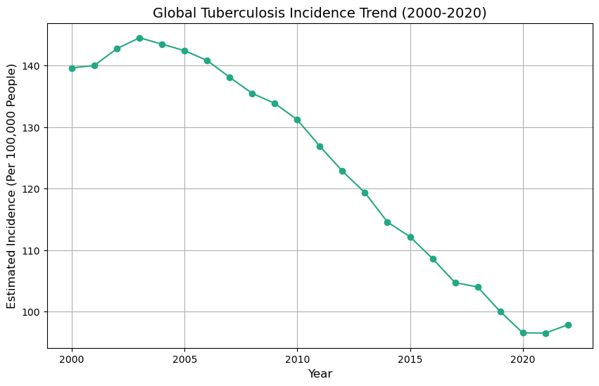

```python
# Group the TB incidence data by year to get the global trend
global_tb_incidence = df_tb_incidence.groupby('Year')['Estimated incidence of all forms of tuberculosis'].mean()

# Plot Global TB Incidence Trend
plt.figure(figsize=(10, 6))
plt.plot(global_tb_incidence.index, global_tb_incidence.values, marker='o', color=viridis(0.6))
plt.title('Global Tuberculosis Incidence Trend (2000-2020)', fontsize=14)
plt.xlabel('Year', fontsize=12)
plt.ylabel('Estimated Incidence (Per 100,000 People)', fontsize=12)
plt.grid(True)
plt.show()
```

# Key Question: How does the TB case detection rate relate to the treatment success rate?

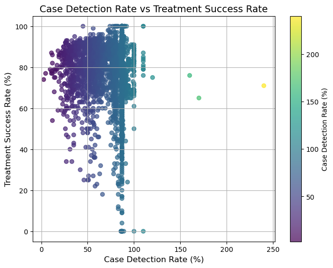

```python
# Merge the TB detection and treatment success datasets
df_detection_treatment = pd.merge(
    df_tb_detection_rate[['Entity', 'Year', 'Case detection rate (all forms)']],
    df_tb_treatment_success[['Entity', 'Year', 'Indicator:Treatment success rate: new TB cases']],
    on=['Entity', 'Year']
)

# Drop rows with missing values
df_detection_treatment_clean = df_detection_treatment.dropna()

# Scatter plot of Case Detection Rate vs Treatment Success Rate
plt.figure(figsize=(8, 6))
plt.scatter(df_detection_treatment_clean['Case detection rate (all forms)'],
            df_detection_treatment_clean['Indicator:Treatment success rate: new TB cases'],
            alpha=0.7, c=df_detection_treatment_clean['Case detection rate (all forms)'], cmap='viridis')

plt.title('Case Detection Rate vs Treatment Success Rate', fontsize=14)
plt.xlabel('Case Detection Rate (%)', fontsize=12)
plt.ylabel('Treatment Success Rate (%)', fontsize=12)
plt.colorbar(label='Case Detection Rate (%)')
plt.grid(True)
plt.show()
```

# Key Question: How has the share of TB patients co-infected with HIV changed over time?

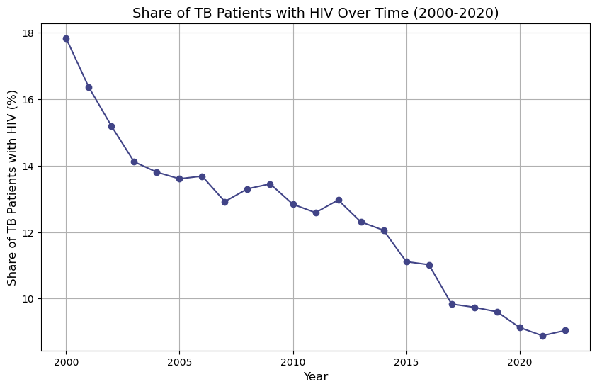

```python
# Group the TB-HIV dataset by year to get the average share of TB patients with HIV
tb_hiv_share_by_year = df_tb_hiv_share.groupby('Year')['Estimated HIV in incident tuberculosis'].mean()

# Plot the share of TB patients with HIV over time
plt.figure(figsize=(10, 6))
plt.plot(tb_hiv_share_by_year.index, tb_hiv_share_by_year.values, marker='o', color=viridis(0.2))
plt.title('Share of TB Patients with HIV Over Time (2000-2020)', fontsize=14)
plt.xlabel('Year', fontsize=12)
plt.ylabel('Share of TB Patients with HIV (%)', fontsize=12)
plt.grid(True)
plt.show()
```